# Thymus humain – signalisation stroma ↔ cellules T

Reproduction du paragraphe « signalling factors known to be involved in thymic development » et de la fig. S11 de Park et al., *Science* 367, eaay3224 (2020) · fichier HTA08_v01_A05_Science_human_fig1.h5ad (255 901 cellules) · CellPhoneDB 5.0.1

**4/4**affirmations du papier retrouvées

**99**groupes type × stade (≥50 cellules)

**3293**couples testés (même stade)

**297/706**paires de la table S5 significatives chez nous

## 1. Reproduction de la fig. S11

Comme dans le papier : types cellulaires (`Anno_level_fig1`) séparés par stade (early 7–11 pcw, middle 12 pcw–10 mois, late ≥15 mois), groupes de moins de 50 cellules omis. Toutes les cellules sont utilisées. Pourcentages = part des cellules du groupe qui expriment le gène.

| Axe | Ce que dit le papier | Ce que l'on mesure | Verdict | Nuance |
| --- | --- | --- | --- | --- |
| **LTB:LTBR** | LTB vient de cellules immunes variées ; LTBR est reçu par la plupart des cellules stromales. | LTB : 10/10 des groupes les plus exprimants sont immuns (CD4+Tmem_early (97%), CD4+Tmem_middle (96%), ILC3_middle (96%), ILC3_early (94%)…). LTBR détecté dans ≥20 % des cellules pour 25/29 groupes str… | retrouvé | LTBR est aussi exprimé par les DC et les macrophages. |
| **RANKL:RANK** | Signal limité aux ILC3 → mTEC(II) / endothélium lymphatique. | TNFSF11 (RANKL) dans ≥20 % des cellules : ILC3_late (28%), ILC3_middle (25%), ILC3_early (26%) uniquement. TNFRSF11A (RANK) dans ≥20 % : mTEC(II)_early (54%), mTEC(II)_middle (45%), Lymph_late (24%), … | retrouvé |  |
| **FGF7:FGFR2** | FGF7 vient des fibroblastes vers les TEC ; FGFR2 baisse chez l'adulte. | FGF7 dans ≥50 % des cellules : Fb_1, Fb_2, Fb_cycling, VSMC. FGFR2, expression moyenne early → middle → late : cTEC 0.66 → 0.15 → —; mTEC(I) — → 0.56 → 0.28; mTEC(II) 0.67 → 0.21 → —; mTEC(III) — → 0.… | retrouvé | FGF7 aussi dans les VSMC. Baisse testable sur les mTEC seulement : les cTEC late ont <50 cellules. |
| **Notch** | NOTCH1 = principal récepteur des ETP ; JAG2 et DLL4 sur cTEC et endothélium ; JAG1 sur les autres TEC. | Dans les ETP, NOTCH1 est le récepteur Notch le plus exprimé à chaque stade (ETP_early : NOTCH1 0.66 vs NOTCH2–4 ≤ 0.18; ETP_late : NOTCH1 0.56 vs NOTCH2–4 ≤ 0.25; ETP_middle : NOTCH1 0.94 vs NOTCH2–4 … | retrouvé | JAG1 est aussi fort dans les VSMC. |

**Voir le dot plot (taille = % de cellules qui expriment, couleur = moyenne rapportée au maximum du gène)**

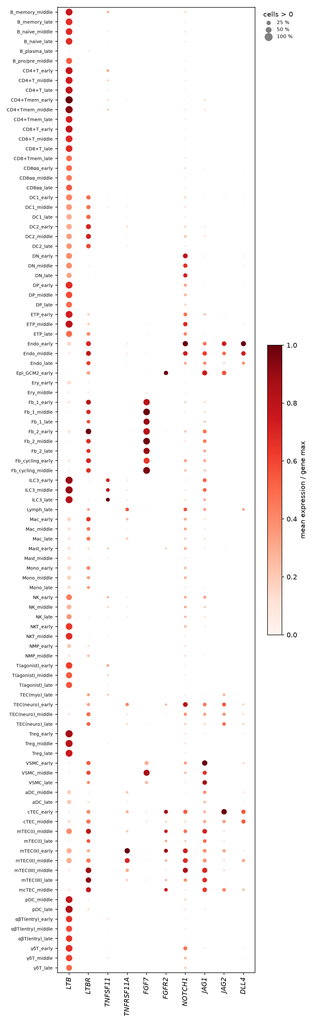

## 2. CellPhoneDB par stade

Même protocole que les auteurs (≤1000 cellules par groupe, 1000 permutations), avec un groupe par type × stade et une analyse CellPhoneDB par stade (une analyse unique de 99 groupes dépassait la mémoire disponible). Valeurs = p-value de CellPhoneDB, sender et receiver au même stade. Vert : p < 0,05. « absent » : groupe de moins de 50 cellules.

### `TNFSF11_TNFRSF11A`

| sender → receiver | early | middle | late |
| --- | --- | --- | --- |
| ILC3 → mTEC(II) | 0.000 | 0.000 | absent |
| ILC3 → Lymph | absent | absent | 0.000 |

### `FGF7_FGFR2`

| sender → receiver | early | middle | late |
| --- | --- | --- | --- |
| Fb_1 → cTEC | 0.000 | 1.000 | absent |
| Fb_1 → mTEC(I) | absent | 0.000 | 1.000 |
| Fb_1 → mTEC(II) | 0.000 | 0.000 | absent |
| Fb_1 → mTEC(III) | absent | 1.000 | 0.000 |
| Fb_1 → mcTEC | absent | 0.000 | absent |
| Fb_2 → cTEC | 0.000 | 1.000 | absent |
| Fb_2 → mTEC(I) | absent | 0.000 | 1.000 |
| Fb_2 → mTEC(II) | 0.000 | 0.000 | absent |
| Fb_2 → mTEC(III) | absent | 1.000 | 0.000 |
| Fb_2 → mcTEC | absent | 0.000 | absent |

### `DLL4_NOTCH1`

| sender → receiver | early | middle | late |
| --- | --- | --- | --- |
| cTEC → ETP | 0.000 | 0.000 | absent |
| Endo → ETP | 0.000 | 0.000 | 0.000 |
| mTEC(I) → ETP | absent | 1.000 | 1.000 |
| mTEC(II) → ETP | 1.000 | 0.000 | absent |
| mTEC(III) → ETP | absent | 1.000 | 1.000 |
| mcTEC → ETP | absent | 0.000 | absent |

### `JAG2_NOTCH1`

| sender → receiver | early | middle | late |
| --- | --- | --- | --- |
| cTEC → ETP | 0.000 | 0.000 | absent |
| Endo → ETP | 0.000 | 0.000 | 1.000 |
| mTEC(I) → ETP | absent | 1.000 | 1.000 |
| mTEC(II) → ETP | 0.000 | 1.000 | absent |
| mTEC(III) → ETP | absent | 1.000 | 1.000 |
| mcTEC → ETP | absent | 0.000 | absent |

### `JAG1_NOTCH1`

| sender → receiver | early | middle | late |
| --- | --- | --- | --- |
| cTEC → ETP | 0.000 | 0.000 | absent |
| Endo → ETP | 0.000 | 0.000 | 0.000 |
| mTEC(I) → ETP | absent | 0.000 | 0.000 |
| mTEC(II) → ETP | 0.000 | 0.000 | absent |
| mTEC(III) → ETP | absent | 0.000 | 0.000 |
| mcTEC → ETP | absent | 0.000 | absent |

### `LTB_LTBR`

| stade | couples significatifs (même stade) | dont cellule immune → stroma |
| --- | --- | --- |
| early | 204 | 131 (64%) |
| middle | 304 | 197 (65%) |
| late | 223 | 146 (65%) |

## 3. Vue d'ensemble, stades regroupés

Nombre de paires ligand–récepteur significatives (p < 0,05) avec le ligand dans la ligne et le récepteur dans la colonne. Seules les interactions de type ligand–récepteur sont comptées, orientées d'après la base (corrigé : la version précédente mélangeait les paires d'adhésion et ne tenait pas compte des 77 paires où le récepteur est en premier).

| ligand ↓ / récepteur → | DN | DP | αβT(entry) | CD4+T | CD8+T | CD4+Tmem | CD8+Tmem | Treg | T(agonist) | CD8αα | γδT |
| --- | --- | --- | --- | --- | --- | --- | --- | --- | --- | --- | --- |
| cTEC | 33 | 33 | 15 | 24 | 18 | 24 | 20 | 27 | 22 | 20 | 49 |
| mTEC(I) | 26 | 21 | 11 | 22 | 16 | 27 | 21 | 22 | 17 | 19 | 32 |
| mTEC(II) | 47 | 46 | 26 | 41 | 28 | 44 | 36 | 42 | 35 | 35 | 62 |
| mcTEC | 38 | 36 | 19 | 31 | 20 | 30 | 25 | 28 | 24 | 25 | 48 |
| DC1 | 18 | 17 | 13 | 17 | 17 | 22 | 21 | 22 | 15 | 17 | 22 |
| DC2 | 22 | 20 | 14 | 27 | 21 | 30 | 25 | 28 | 21 | 20 | 26 |
| aDC | 18 | 16 | 11 | 23 | 13 | 27 | 18 | 21 | 19 | 17 | 23 |
| pDC | 15 | 16 | 10 | 14 | 14 | 17 | 18 | 19 | 13 | 16 | 20 |
| Fb_1 | 25 | 22 | 13 | 20 | 18 | 24 | 20 | 20 | 19 | 15 | 32 |
| Fb_2 | 32 | 27 | 12 | 24 | 19 | 25 | 21 | 23 | 20 | 14 | 43 |
| Endo | 32 | 30 | 14 | 27 | 21 | 28 | 23 | 25 | 20 | 18 | 40 |

## 4. Comparaison avec la table S5

- Comparaison par identifiants des partenaires, sans tenir compte de l'ordre (la table S5 écrit souvent `IL7 receptor_IL7` là où notre base écrit `IL7_IL7_receptor`).
- 706 paires dans la table S5 ; 342 existent dans notre base v5 ; 297 y sont significatives.
- Les paires absentes viennent de l'ancienne version de CellPhoneDB (par exemple `CXCL12_CXCR3`, récepteurs ACKR).
- Reproduction exacte impossible avec ce fichier : la table S5 couvre environ 53 types, dont certains absents du h5ad (`NCC`, `Muscle_progenitors`, `Epi_PAX8`, `Fb_early`, `TEC_early`).

## Limites et suite

- Le stade est très lié au type cellulaire : cTEC 96 % early, mTEC(I) 79 % late, endothélium 92 % late. Les comparaisons entre stades ne valent que pour quelques types.
- Petits groupes : ETP 316 cellules, endothélium lymphatique 115.
- Moitié des cellules en chimie 3', moitié en 5' : à inclure comme variable de contexte dans MIIC.

**Étape suivante : CausalCCC, un axe à la fois.** 1) FGF7:FGFR2, fibroblastes → TEC ; 2) RANKL, ILC3 → mTEC(II) ; 3) Notch, TEC → ETP ; 4) LTB:LTBR en dernier (signal diffus). Pour MIIC, toutes les cellules des types choisis, avec le stade et la chimie comme variables de contexte.